# Data Integration Tutorial

Zain Arifin

July 01, 2025

## Introduction

Today, we will have a look at data integration with MOFA2. Briefly, the data consists of four omics including DNA methylation, RNA-seq, somatic mutations and drug response data from blood for N=200 patients with Chronic Lymphocytic Leukemia (CLL). The data set is explained in detail in this article: https://www.jci.org/articles/view/93801. One caveat about MOFA2 is that it can only be used for integrating data that are matched. For unmatched, please have a look at mechanistic-based or graph-based integration.

## Load data

```r
options(future.globals.maxSize = 10 * 1024^3)

library(MOFA2)
library(MOFAdata)
library(data.table)
library(tidyverse)
```

```r
utils::data("CLL_data")
lapply(CLL_data,dim)
```

```
## $Drugs
## [1] 310 200
##
## $Methylation
## [1] 4248  200
##
## $mRNA
## [1] 5000  200
##
## $Mutations
## [1]  69 200
```

```r
CLL_data$Drugs[1:5,1:5]
```

```
##               H045      H109 H024       H056       H079
## D_001_1 0.02363938 0.0735990   NA 0.05813930 0.02042077
## D_001_2 0.04623274 0.1062300   NA 0.09022028 0.04750543
## D_001_3 0.31874706 0.2732891   NA 0.23221452 0.36389622
## D_001_4 0.82370272 0.7171379   NA 0.72257364 0.80739074
## D_001_5 0.89627769 0.8850003   NA 0.79574966 0.87948865
```

```r
CLL_data$Methylation[1:5,1:5]
```

```
##                  H045      H109       H024       H056        H079
## cg10146935  1.8110858 -3.997508 -2.8443130 -3.3386561 -0.01936203
## cg26837773 -5.1725723  1.594870  0.1611705 -2.0934326  3.74897956
## cg17801765  5.4115263  5.412693  0.3657059  0.3736342  5.41200957
## cg13244315 -0.1188251  1.043871 -4.2192362 -1.5921965  1.41641834
## cg06181703  5.1203838  1.279480  0.7211004  4.0470594  5.23742246
```

```r
CLL_data$Mutations[1:5,1:5]
```

```
##            H045 H109 H024 H056 H079
## gain2p25.3    0    0    0    0    1
## gain3q26      0    0    0    0    0
## del6p21.2     0    0    0    0    0
## del6q21       0    0    0    0    0
## del8p12       0    0    0    0    0
```

```r
CLL_data$mRNA[1:5,1:5]
```

```
##                      H045      H109      H024      H056      H079
## ENSG00000244734  4.558644  2.721512  9.938456 13.278004  6.086874
## ENSG00000158528 11.741854 13.287432  2.341006  3.232874 11.940820
## ENSG00000198478  8.921456  2.721512 12.381452  8.106266  4.889503
## ENSG00000175445 12.686458 10.925985  1.528848  1.528848 13.340588
## ENSG00000174469  2.644946 12.648355  1.528848 13.565210  5.476914
```

```r
CLL_metadata <- fread("ftp://ftp.ebi.ac.uk/pub/databases/mofa/cll_vignette/sample_metadata.txt")
head(CLL_metadata)
```

```
##    sample Gender      age        TTT      TTD treatedAfter   died  IGHV
##    <char> <char>    <num>      <num>    <num>       <lgcl> <lgcl> <int>
## 1:   H005      m 75.26575 0.57494867 2.625599         TRUE  FALSE     1
## 2:   H006      m       NA         NA       NA           NA     NA    NA
## 3:   H007      f       NA         NA       NA           NA     NA    NA
## 4:   H008      m       NA         NA       NA           NA     NA    NA
## 5:   H010      f 72.78082 2.93223819 2.932238        FALSE  FALSE     0
## 6:   H011      f 72.99452 0.01916496 2.951403         TRUE  FALSE     1
##    trisomy12
##        <int>
## 1:         0
## 2:        NA
## 3:        NA
## 4:        NA
## 5:         0
## 6:         0
```

Sample metadata are stored as a data.frame. Important columns are:

Gender: m (male), f (female) Age: age in years TTT: time (in years) which passed from taking the sample to the next treatment TTD: time (in years) which passed from taking the sample to patients’ death treatedAfter: (TRUE/FALSE) Died: whether the patient died (TRUE/FALSE)

## Run MOFA

Prior to running, please make sure that each omic data has been individually normalized. There is an argument to also scale the data, such that each omic should be in the same numerical scale (if data is numeric). However, this is entirely dependent on what data you are working with. For more information on MOFA, have a look at their FAQ page: https://biofam.github.io/MOFA2/faq.html

```r
MOFAobject <- create_mofa(CLL_data)
```

```
## Creating MOFA object from a list of matrices (features as rows, sample as columns)...
```

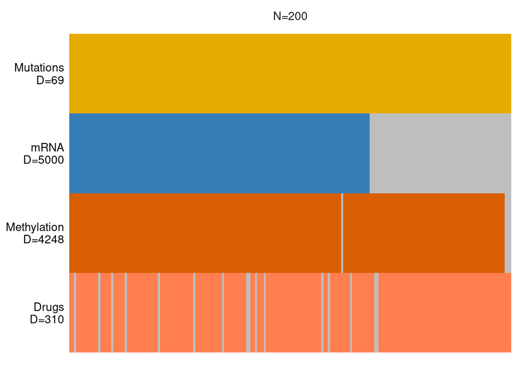

```r
plot_data_overview(MOFAobject)
```

```r
data_opts <- get_default_data_options(MOFAobject)
data_opts
```

```
## $scale_views
## [1] FALSE
##
## $scale_groups
## [1] FALSE
##
## $center_groups
## [1] TRUE
##
## $use_float32
## [1] TRUE
##
## $views
## [1] "Drugs"       "Methylation" "mRNA"        "Mutations"
##
## $groups
## [1] "group1"
```

```r
model_opts <- get_default_model_options(MOFAobject)
model_opts
```

```
## $likelihoods
##       Drugs Methylation        mRNA   Mutations
##  "gaussian"  "gaussian"  "gaussian"  "gaussian"
##
## $num_factors
## [1] 15
##
## $spikeslab_factors
## [1] FALSE
##
## $spikeslab_weights
## [1] FALSE
##
## $ard_factors
## [1] FALSE
##
## $ard_weights
## [1] TRUE
```

```r
train_opts <- get_default_training_options(MOFAobject)
train_opts$convergence_mode <- "slow"
train_opts$seed <- 110

train_opts
```

```
## $maxiter
## [1] 1000
##
## $convergence_mode
## [1] "slow"
##
## $drop_factor_threshold
## [1] -1
##
## $verbose
## [1] FALSE
##
## $startELBO
## [1] 1
##
## $freqELBO
## [1] 5
##
## $stochastic
## [1] FALSE
##
## $gpu_mode
## [1] FALSE
##
## $gpu_device
## NULL
##
## $seed
## [1] 110
##
## $outfile
## NULL
##
## $weight_views
## [1] FALSE
##
## $save_interrupted
## [1] FALSE
```

```r
MOFAobject <- prepare_mofa(MOFAobject,
  data_options = data_opts,
  model_options = model_opts,
  training_options = train_opts
)
```

```
## Checking data options...
```

```
## Checking training options...
```

```
## Checking model options...
```

```r
MOFAobject <- run_mofa(MOFAobject,
                       outfile="MOFA2_CLL.hdf5",
                       use_basilisk = T)
```

```
## Connecting to the mofapy2 package using basilisk.
##     Set 'use_basilisk' to FALSE if you prefer to manually set the python binary using 'reticulate'.
```

[output not shown]

[output cut: 955 more lines]

[output not shown]

```r
# The first training you do with MOFA will take some time as they will install the required Python dependency

# Add sample metadata to the model
samples_metadata(MOFAobject) <- CLL_metadata
```

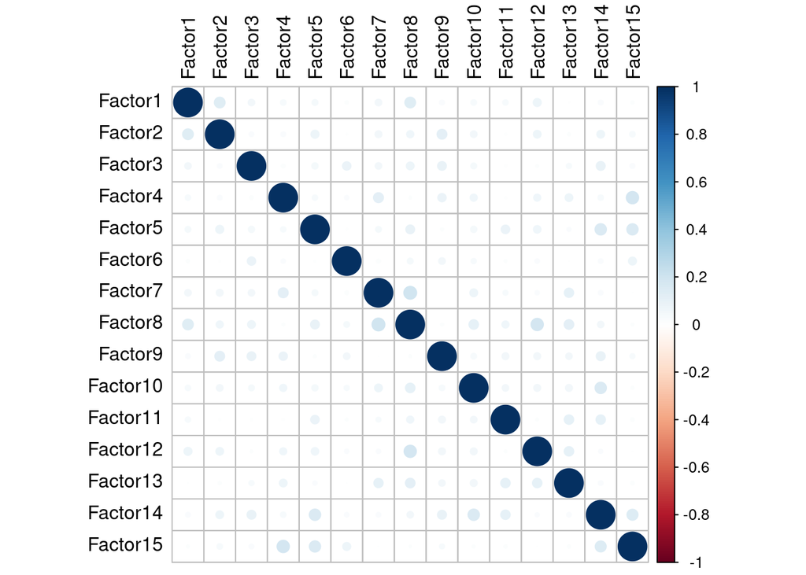

```r
plot_factor_cor(MOFAobject)
```

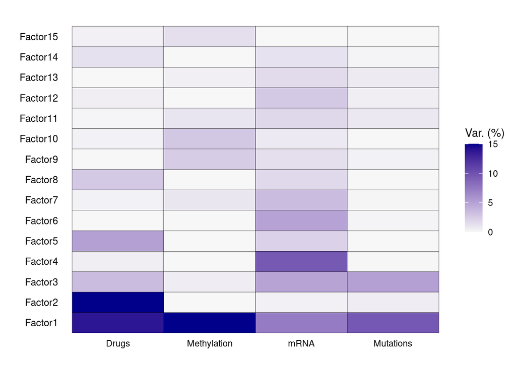

```r
plot_variance_explained(MOFAobject, max_r2=15)
```

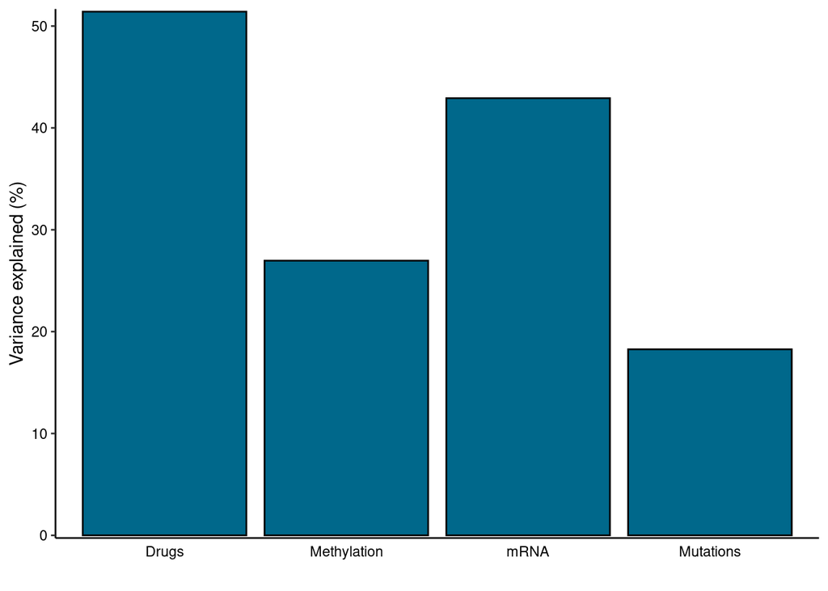

```r
plot_variance_explained(MOFAobject, plot_total = T)[[2]]
```

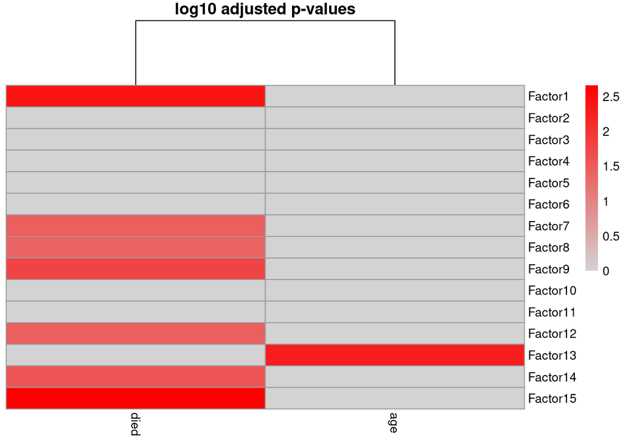

```r
correlate_factors_with_covariates(MOFAobject,
  covariates = c("died","age"),
  plot="log_pval"
)
```

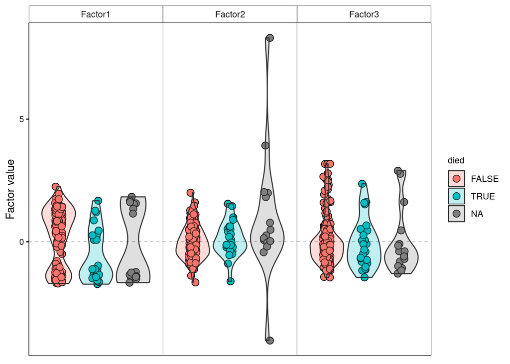

```r
p <- plot_factor(MOFAobject,
  factors = c(1,2,3),
  color_by = "died",
  dot_size = 3,        # change dot size
  dodge = TRUE,           # dodge points with different colors
  legend = TRUE,          # remove legend
  add_violin = TRUE,      # add violin plots,
  violin_alpha = 0.25  # transparency of violin plots
)
p
```

## Analyze MOFA weights

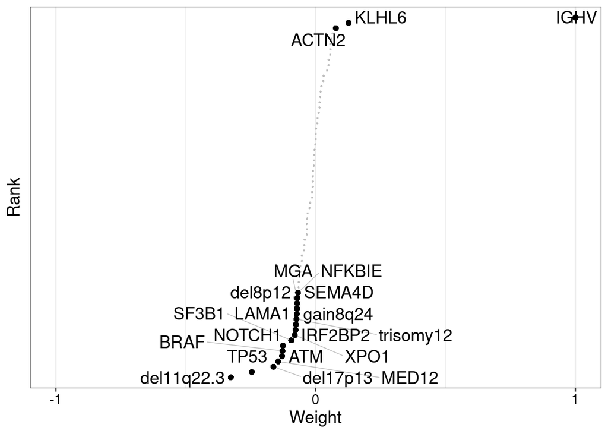

```r
plot_weights(MOFAobject,
 view = "Mutations",
 factor = 1,
 nfeatures = 20,     # Top number of features to highlight
 scale = T           # Scale weights from -1 to 1
)
```

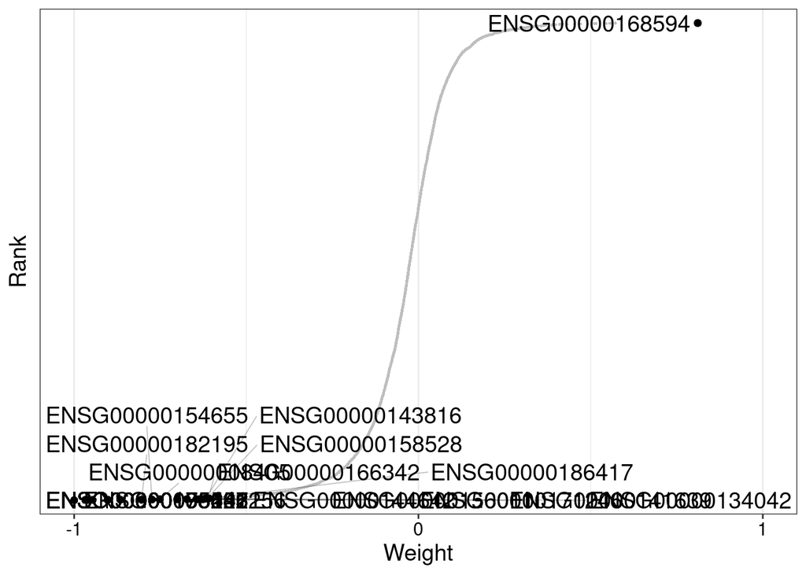

```r
plot_weights(MOFAobject,
 view = "mRNA",
 factor = 1,
 nfeatures = 20,     # Top number of features to highlight
 scale = T           # Scale weights from -1 to 1
)
```

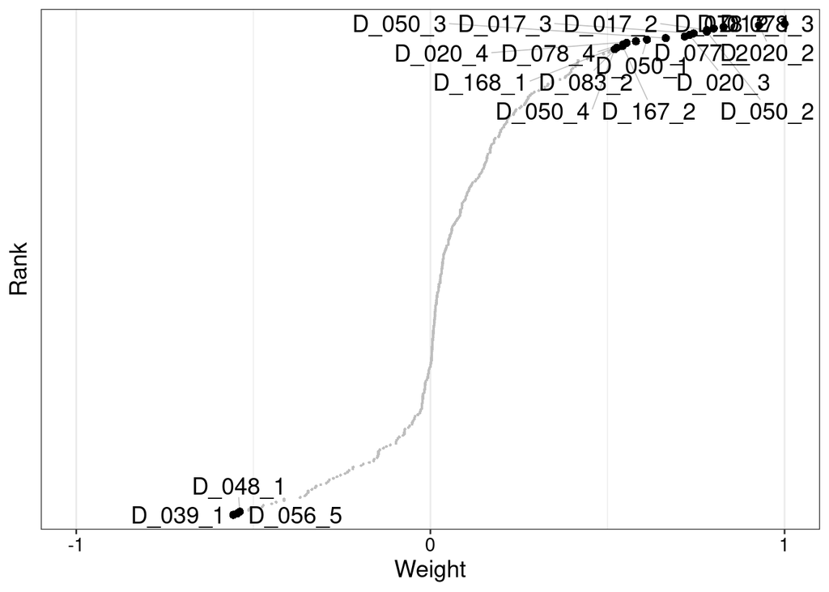

```r
plot_weights(MOFAobject,
 view = "Drugs",
 factor = 1,
 nfeatures = 20,     # Top number of features to highlight
 scale = T           # Scale weights from -1 to 1
)
```

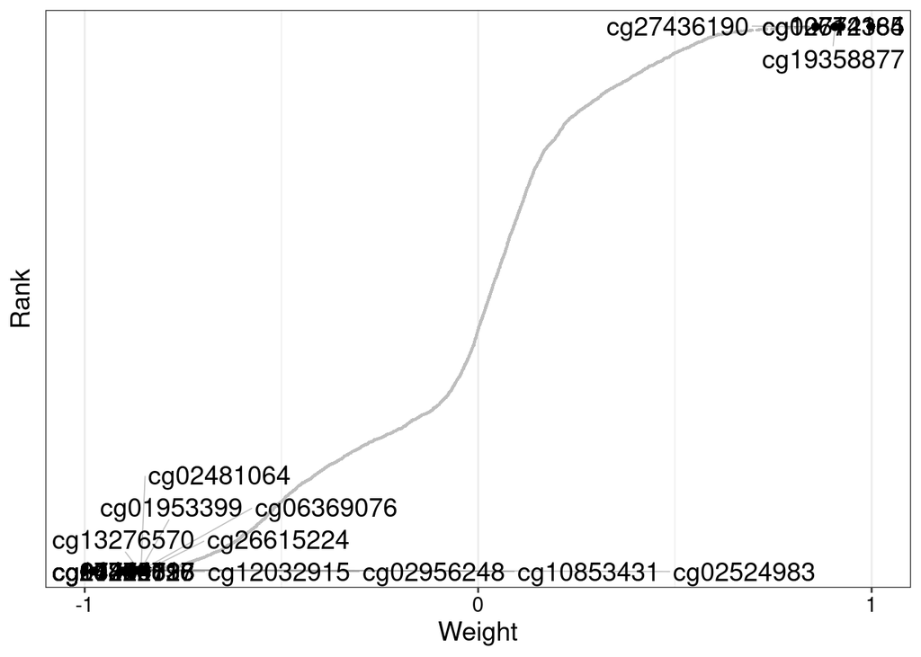

```r
plot_weights(MOFAobject,
 view = "Methylation",
 factor = 1,
 nfeatures = 20,     # Top number of features to highlight
 scale = T           # Scale weights from -1 to 1
)
```

We see that for mutation IGHV is one of the main source of variation in factor. Lets confirm this with UMAP.

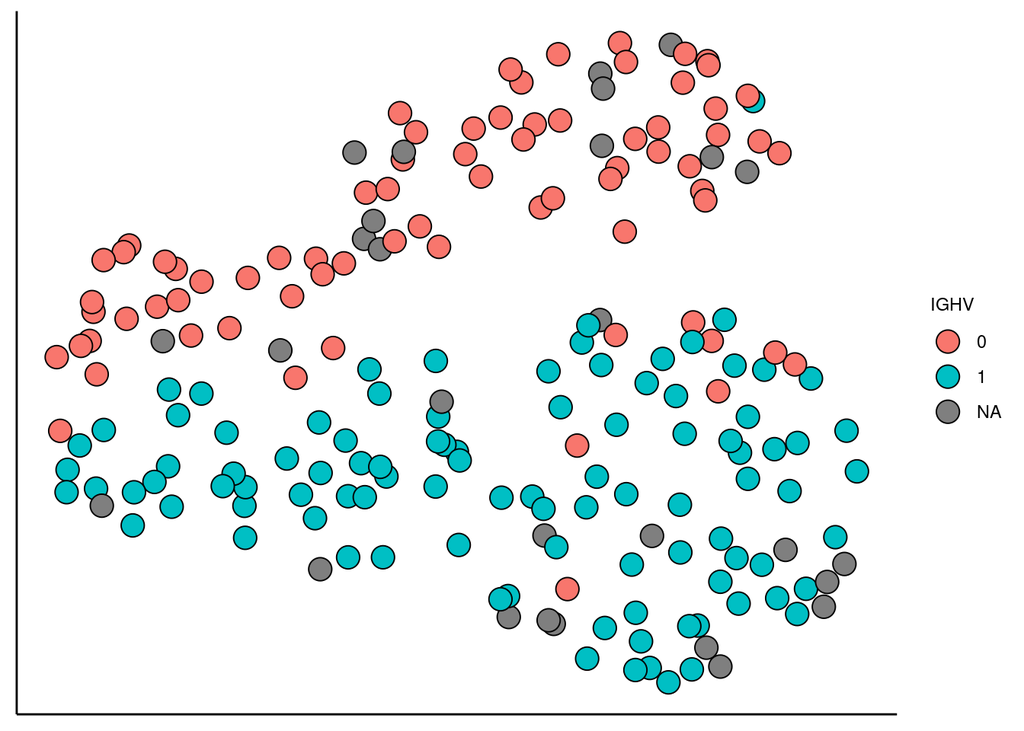

```r
set.seed(1)
MOFAobject <- run_umap(MOFAobject)

plot_dimred(MOFAobject,
  method = "UMAP",
  color_by = "IGHV",
  dot_size = 5
)
```

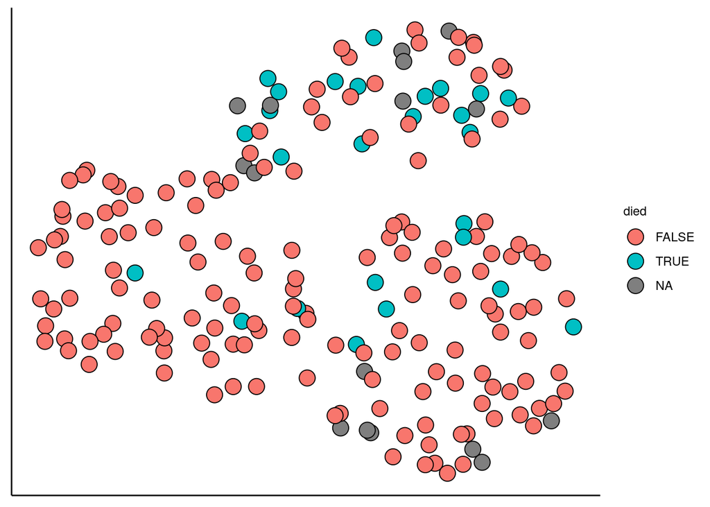

```r
plot_dimred(MOFAobject,
  method = "UMAP",
  color_by = "died",
  dot_size = 5
)
```

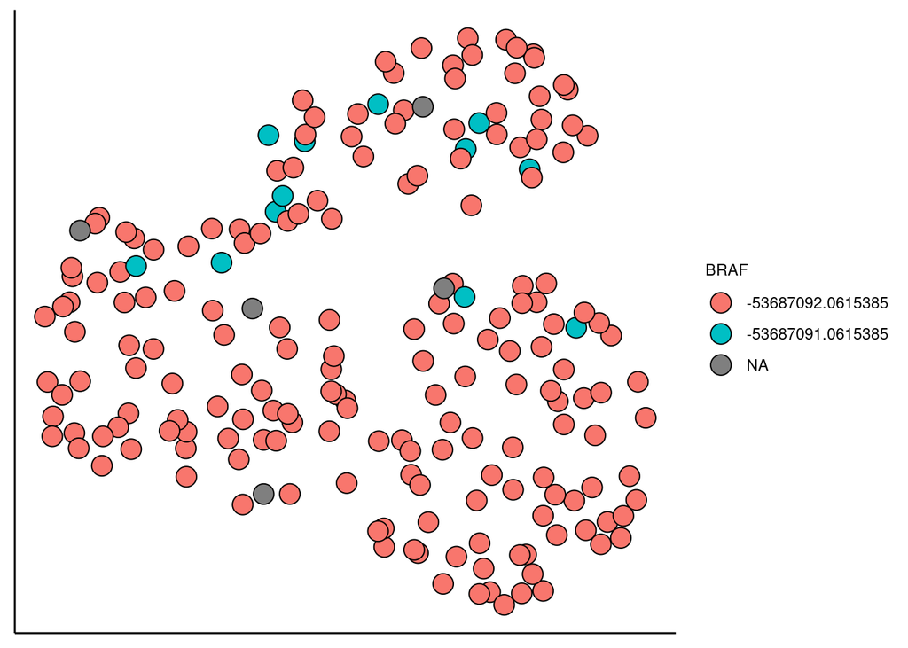

```r
# Check others

# BRAF mutation
plot_dimred(MOFAobject,
  method = "UMAP",
  color_by = "BRAF",
  dot_size = 5, groups = "all"
)
```

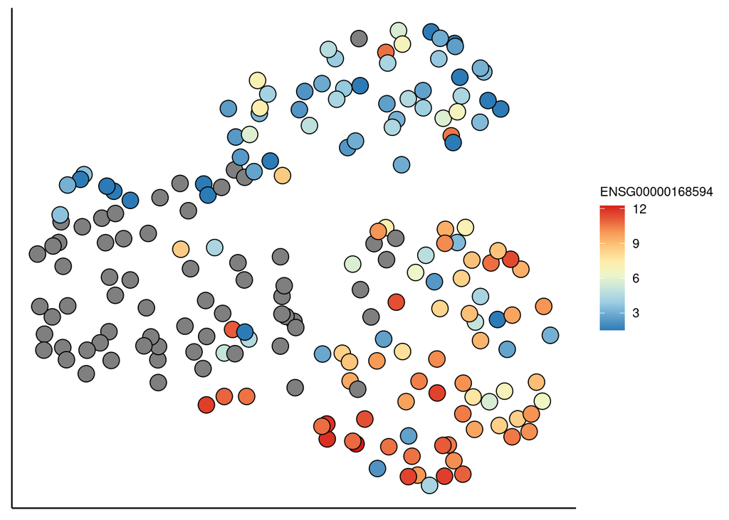

```r
# ENSG00000168594/ADAM29 expression
plot_dimred(MOFAobject,
  method = "UMAP",
  color_by = "ENSG00000168594",
  dot_size = 5, groups = "all"
)
```

There are more analyses that can be done with MOFA2. Please have a look at MOFA documentations and try to complete the following task:

1. Perform survival analysis using Factor 1 (or other factors) as weight
2. Run gene set enrichment (GSEA) analysis or over-representation analysis on Factor 1
3. Explore Drugs and methylation variables and identify its biological significane towards CLL.
4. From the data integration, what conclusion can you pull when you combine these 4 omics layers? Try to link up all the findings you get from each layer and build up a possible biological explanation.